# final-project

# Competetitve Speedcubing Data Analysis

One thing you may not know about me is that I’m a competitive “speedcuber”! Basically, I solve various types of Rubik’s cubes as fast as I can in competitions. We actually run some competitions here at UMD as well! You can find my profile [here](https://www.worldcubeassociation.org/persons/2014RANC01) and learn more here as well.

Cubing Competitions are run in the following way: you solve your cube five times in a “round,” and will advance to later rounds based on your average. There are many different events and types of cubes you can solve, including the standard 3x3x3, bigger cubes such as the 4x4x4-7x7x7, and even other types of solving, such as one handed or blindfolded.

There are two equivalent questions that I’m trying to answer here. One question that people oftern have as they progress and improve is, for example, “what does a sub-20 3x3x3 time coorespond to on a 4x4x4.” Equivalently, I’m curious if we can predict somebodies time in other events based off of their time in at least one other event.

## Getting the Data

I first tried scraping the data directly from the World Cubing Associaction’s (WCA’s) website. Unfortunately, the way the website is laid out isn’t very conducive to scraping - I needed everybodies results in one place. Rather than dealing with that, I found a downloadable version of the dataset that the WCA created [from here](https://www.worldcubeassociation.org/results/misc/export.html). I could also have pulled it directly from their API, but that’s not really necessary for the sake of this analysis.

Luckily, the WCA has a readily made tab-separated-value file for us with every competition result that has ever happened! Unfortunately, this data is not very friendly for our end goal in its current form - we want to know how one persons results affect each other, but the data is set up so that one result for one event is an entity. We will have to process the data to change this.

### Reading in the data

```r
results <- read.table(file = "data/WCA_export_Results.tsv", sep='\t', header=TRUE)
head(results)
```

```
##   competitionId eventId roundTypeId pos best average
## 1  LyonOpen2007     333           1  15 1968    2128
## 2  LyonOpen2007     333           1  16 1731    2140
## 3  LyonOpen2007     333           1  17 2305    2637
## 4  LyonOpen2007     333           1  18 2452    2637
## 5  LyonOpen2007     333           1  19 2677    2906
## 6  LyonOpen2007     333           1  20 1869    2910
##                personName   personId personCountryId formatId value1
## 1           Etienne Amany 2007AMAN01   Cote d_Ivoire        a   1968
## 2          Thomas Rouault 2004ROUA01          France        a   2222
## 3 Antoine Simon-Chautemps 2005SIMO01          France        a   3430
## 4         IrÃ¨ne Mallordy 2007MALL01          France        a   2715
## 5     MarlÃ¨ne Desmaisons 2007DESM01          France        a   2921
## 6         Ton Dennenbroek 2003DENN01     Netherlands        a   3309
##   value2 value3 value4 value5 regionalSingleRecord regionalAverageRecord
## 1   2203   2138   2139   2108                  AfR                   AfR
## 2   2153   1731   2334   2046
## 3   2581   2540   2789   2305
## 4   2452   2868   2632   2564
## 5   3184   2891   2677   2907
## 6   1869   2558   2930   3241
```

Unfortunately, this is over 1 million observations, which is way too much data to process effectively. Furthermore, we have many data points for each person - preferable, we just want one data point per person. There are two points for each persons results - an average and a best single. I want to analyze the average here, since the single time is more dependant on luck. However, theres’ two possible ways we could do this. We can either check the minimum average, which is generally what the community would prefer, or the average of the average, which might be a better metric. I will try both here! First, since there’s no year column, we’ll have to extract that from the competition name.

### Tidying and Transforming the data

```r
results <- mutate(results, year=stringr::str_extract(competitionId, "\\d{4}"))
```

The first thing we want to do is remove entities that are “Did Not Finish,” “Did Not Start,” or “No Result” events. The data set encodes these as -1, -2, and 0, respectively. These manipulate our dataset in a really undesired way, since they’re lower than any possible average. It’s easiest to just remove these entitites entirely.

```r
results <- filter(results, average > 0)
head(results)
```

```
##   competitionId eventId roundTypeId pos best average
## 1  LyonOpen2007     333           1  15 1968    2128
## 2  LyonOpen2007     333           1  16 1731    2140
## 3  LyonOpen2007     333           1  17 2305    2637
## 4  LyonOpen2007     333           1  18 2452    2637
## 5  LyonOpen2007     333           1  19 2677    2906
## 6  LyonOpen2007     333           1  20 1869    2910
##                personName   personId personCountryId formatId value1
## 1           Etienne Amany 2007AMAN01   Cote d_Ivoire        a   1968
## 2          Thomas Rouault 2004ROUA01          France        a   2222
## 3 Antoine Simon-Chautemps 2005SIMO01          France        a   3430
## 4         IrÃ¨ne Mallordy 2007MALL01          France        a   2715
## 5     MarlÃ¨ne Desmaisons 2007DESM01          France        a   2921
## 6         Ton Dennenbroek 2003DENN01     Netherlands        a   3309
##   value2 value3 value4 value5 regionalSingleRecord regionalAverageRecord
## 1   2203   2138   2139   2108                  AfR                   AfR
## 2   2153   1731   2334   2046
## 3   2581   2540   2789   2305
## 4   2452   2868   2632   2564
## 5   3184   2891   2677   2907
## 6   1869   2558   2930   3241
##   year
## 1 2007
## 2 2007
## 3 2007
## 4 2007
## 5 2007
## 6 2007
```

```r
min_avgs <- filter(results, year >= 2017) %>%
  group_by(personId, eventId) %>% summarize(avg=min(average)/100)
avg_avgs <- filter(results, year >= 2017) %>%
  group_by(personId, eventId) %>% summarize(avg=mean(average)/100)
head(min_avgs)
```

```
## # A tibble: 6 x 3
## # Groups:   personId [2]
##   personId   eventId   avg
##   <fct>      <fct>   <dbl>
## 1 1982RAZO01 333fm   28.7
## 2 2003BRUC01 222      5.32
## 3 2003BRUC01 333     12.7
## 4 2003BRUC01 333fm   37
## 5 2003BRUC01 333oh   33.4
## 6 2003BRUC01 444     47.0
```

There are still about 200,000 observations here, which is a lot but is also a lot better! This data isn’t very tidy, so we’d like to transform it in the following way: the primary key should be someones WCA ID. To do this, we can `spread` based on the eventId. We could have started by doing this, but it would have been operating on a much larger data set and taken a very long time then. Note that to do this, we need to assign each person a unique, integer id, as that’s how the spread function determines what an entity is. We then remove this attribute, since it’s not actually relevant for our analysis.

```r
avg_avgs$i <- avg_avgs %>% group_by(personId) %>% group_indices
min_avgs$i <- min_avgs %>% group_by(personId) %>% group_indices
min_avgs <- spread(min_avgs, eventId, "avg") %>% select(-i) %>% ungroup()
avg_avgs <- spread(avg_avgs, eventId, "avg") %>% select(-i) %>% ungroup()
head(avg_avgs)
```

```
## # A tibble: 6 x 18
##   personId `222` `333` `333bf` `333fm` `333ft` `333oh` `444` `444bf` `555`
##   <fct>    <dbl> <dbl>   <dbl>   <dbl>   <dbl>   <dbl> <dbl>   <dbl> <dbl>
## 1 1982RAZ~ NA     NA       NA     28.7      NA    NA    NA        NA   NA
## 2 2003BRU~  7.37  15.0     NA     37.5      NA    37.2  52.9      NA  107.
## 3 2003BUR~  7.76  22.9     NA     45.2      NA    39.1  NA        NA   NA
## 4 2003DEN~  9.80  19.8     NA     NA        NA    64.9  82.1      NA  194.
## 5 2003HAR~  7.15  14.8    133.    34.3      NA    NA    83.8      NA   NA
## 6 2003LEE~ NA     27.5     NA     NA        NA    NA    NA        NA   NA
## # ... with 8 more variables: `555bf` <dbl>, `666` <dbl>, `777` <dbl>,
## #   clock <dbl>, minx <dbl>, pyram <dbl>, skewb <dbl>, sq1 <dbl>
```

Finally, we have a lot of missing attributes here. I’m going to fill these in using a regression imputation later on. I don’t want to use the overall mean imputation, because it will be very inaccurate - slower people will have a lower average, while faster people will have a higher one.

## Exploratory Data Analysis

Before modelling this data, we should try to understand it. The best way to do this for most people is visually, so lets create some visualizations of the data!

### Event Distributions

First, let’s look at the distribution of times across some of the events. My prediction here is that most events will be bimodal, with a peak at beginner-level times and intermediate-tier times. To do this, we will create a desnity plot of each event’s times. We’ll also just sort the times and show them in order. This plot can show us that times are generally within a certain range, while also showing extreme outlier relative to it. You also might notice that I’m indexing my passed in dataframe in ggplot - this is an unfortunate requirement due ot the fact that my tables have numericly names columns.

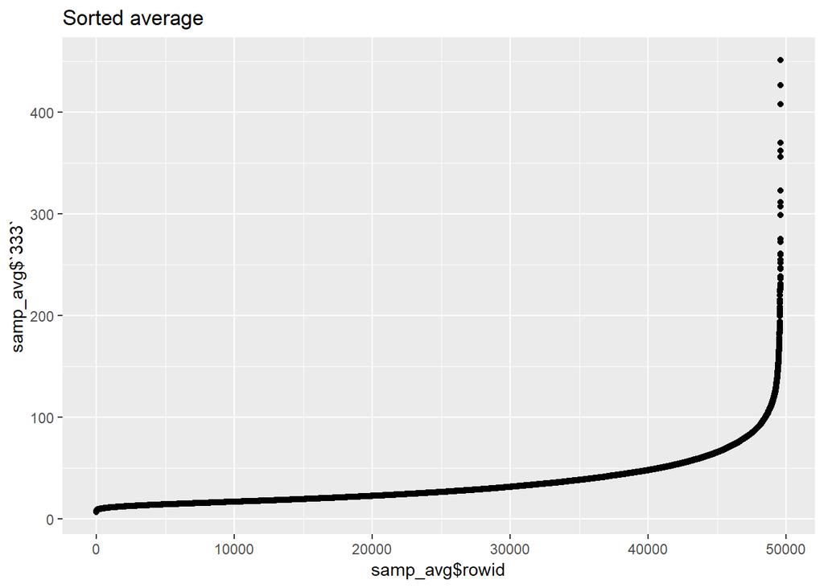

```r
samp_avg <- avg_avgs %>%
  drop_na('333') %>%
  arrange_at(c('333')) %>%
  rowid_to_column()
  ggplot(samp_avg, aes(x=samp_avg$rowid, y=samp_avg$`333`)) + geom_point() + labs(title = "Sorted average")
```

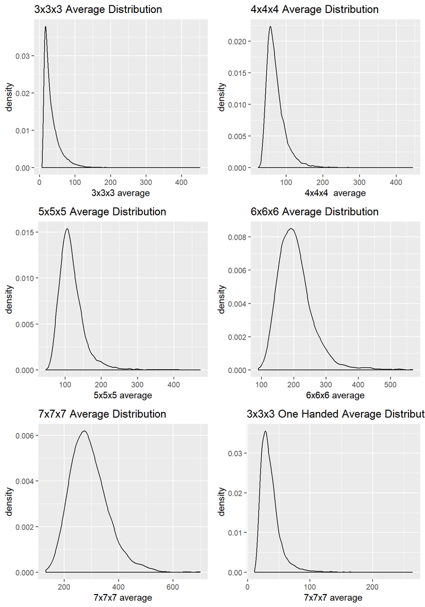

```r
  dist_3 <- ggplot(samp_avg, aes(x=samp_avg$'333')) + geom_density() + labs(title = "3x3x3 Average Distribution", x="3x3x3 average")
  dist_4 <- ggplot(samp_avg, aes(x=samp_avg$'444')) + geom_density() + labs(title = "4x4x4 Average Distribution", x="4x4x4  average")
  dist_5 <- ggplot(samp_avg, aes(x=samp_avg$'555')) + geom_density() + labs(title = "5x5x5 Average Distribution", x="5x5x5 average")
  dist_6 <- ggplot(samp_avg, aes(x=samp_avg$'666')) + geom_density() + labs(title = "6x6x6 Average Distribution", x="6x6x6 average")
  dist_7 <- ggplot(samp_avg, aes(x=samp_avg$'777')) + geom_density() + labs(title = "7x7x7 Average Distribution", x="7x7x7 average")
  dist_3oh <- ggplot(samp_avg, aes(x=samp_avg$'333oh')) + geom_density() + labs(title = "3x3x3 One Handed Average Distribution", x="7x7x7 average")
  print(grid.arrange(dist_3, dist_4, dist_5, dist_6, dist_7, dist_3oh, ncol=2, nrow = 3))
```

Let’s consider the scatter plot first.We can see that most times (40,000 of them) hover somewhere between 5 and 50 seconds. However, the “small” amount of times that happen after that begin increasing rapidly. This is just the results for the 3x3x3 cube, but you can imagine that the rest act similarly. This suggests that my initial bimodal prediction likely will not be accurate.

Interestingly, the distrubtions for 3x3x3 and 3x3x3 One Handed are distubingly similar. However, if you look at the actual counts, much fewer people actually compete in One Handed. The reason for this is that you need some level of previous skill to even solve a cube with one hand, and it ends up not being much slower than normal solving.

One thing that’s really good here is that all of these distrubtions have some level of similarity! This implies that we could transform all data from one distribution into another, which is a very good sign that the model we build will be accurate!

### Relationship Between Events

Since we have so many events here, we need to pick one to act as a “predicted” event time. Since our resulting expression will be a linear model, it doesn’t actually matter what we pick. For simplicity, let’s pick the middle value of the 5x5x5 time as our predicted time. This is also nice because this is one of the most popular events.

We’d then like to investigate the relationship between 5x5x5 times and every other event times. I’d like to make the following point now: I’m not actually investigating “every event.” I’ve cut out a lot of ones that likely have little relationship, like non-cubic puzzles and blindolfed solving, mostly to make my analysis easier. The events I am analyzing is the same as above, which are the following events:

- 3x3x3
- 4x4x4
- 5x5x5
- 6x6x6
- 7x7x7
- 3x3x3 One Handed

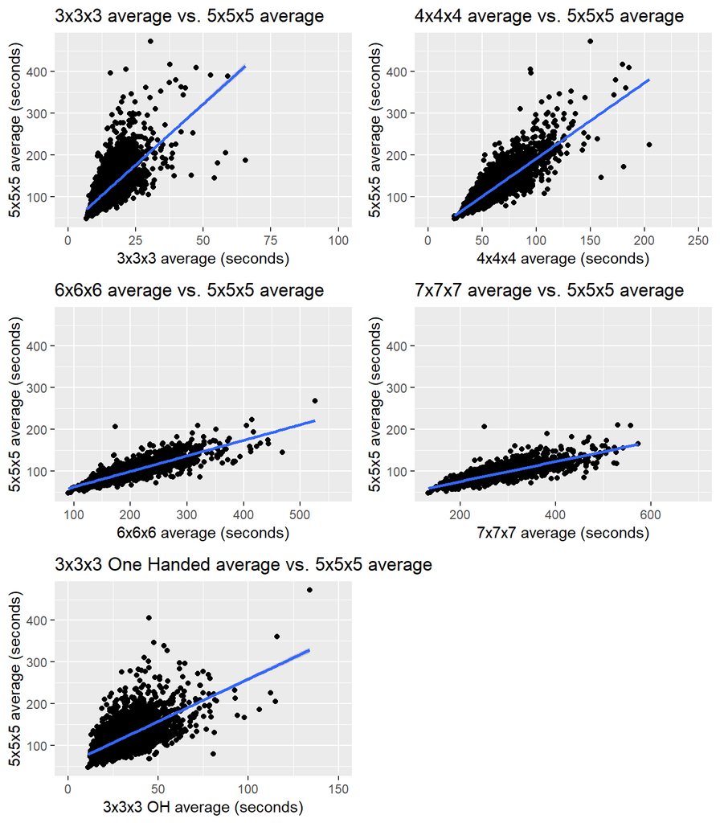

```r
relate_3 <- ggplot(samp_avg, aes(x=samp_avg$'333', y=samp_avg$'555')) + geom_point() + geom_smooth(method=lm) + xlim(0, 100) +
  ggtitle("3x3x3 average vs. 5x5x5 average") + xlab("3x3x3 average (seconds)") + ylab("5x5x5 average (seconds)")
relate_4 <- ggplot(samp_avg, aes(x=samp_avg$'444', y=samp_avg$'555')) + geom_point() + geom_smooth(method=lm) + xlim(0, 250) +
  ggtitle("4x4x4 average vs. 5x5x5 average") + xlab("4x4x4 average (seconds)") + ylab("5x5x5 average (seconds)")
relate_6 <- ggplot(samp_avg, aes(x=samp_avg$'666', y=samp_avg$'555')) + geom_point() + geom_smooth(method=lm) +
  ggtitle("6x6x6 average vs. 5x5x5 average") + xlab("6x6x6 average (seconds)") + ylab("5x5x5 average (seconds)")
relate_7 <- ggplot(samp_avg, aes(x=samp_avg$'777', y=samp_avg$'555')) + geom_point() + geom_smooth(method=lm) +
  ggtitle("7x7x7 average vs. 5x5x5 average") + xlab("7x7x7 average (seconds)") + ylab("5x5x5 average (seconds)")
relate_OH <- ggplot(samp_avg, aes(x=samp_avg$'333oh', y=samp_avg$'555')) + geom_point() + geom_smooth(method=lm) + xlim(0, 150) +
  ggtitle("3x3x3 One Handed average vs. 5x5x5 average") + xlab("3x3x3 OH average (seconds)") + ylab("5x5x5 average (seconds)")
print(grid.arrange(relate_3, relate_4, relate_6, relate_7, relate_OH))
```

These plots are very revealing! In particular, we can see that some terms have a stronger relationship with 5x5x5 average times than others. Particularly, other big cubes, such as 6x6x6 and 7x7x7 serve as better predictors than the 3x3x3 itself does. In terms of how people solve these types of cubes, this makes a lot of sense. The general strategy for solving big cubes is to “reduce” it until you can solve it like a normal 3x3x3, which means that the majority of the solve is identical for 5x5x5-7x7x7.

Unfortunately, another factor of this is that it seems like 3x3x3 time isn’t a fantastic predictor of 5x5x5 time. This gives me another idea - instead of trying to predict 5x5x5 averages for different types of inputs, lets use 3x3x3 as an input and see how we can predict different types of output averages. This is basically the same information but rephrased as a different way, and might show us how 3x3x3 average can actually be used effectively.

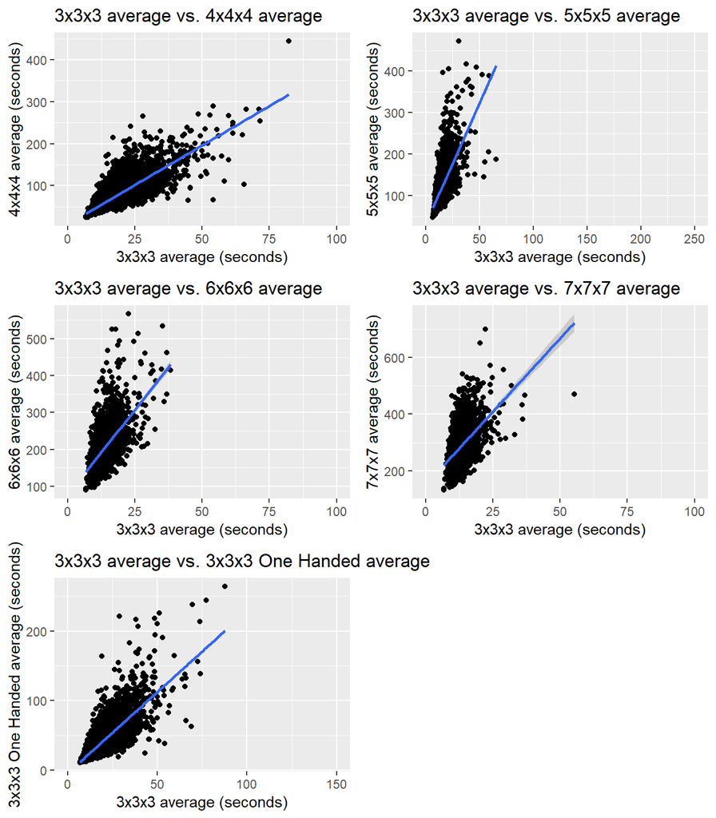

```r
relate_3 <- ggplot(samp_avg, aes(x=samp_avg$'333', y=samp_avg$'444')) + geom_point() + geom_smooth(method=lm) + xlim(0, 100) +
  ggtitle("3x3x3 average vs. 4x4x4 average") + xlab("3x3x3 average (seconds)") + ylab("4x4x4 average (seconds)")
relate_4 <- ggplot(samp_avg, aes(x=samp_avg$'333', y=samp_avg$'555')) + geom_point() + geom_smooth(method=lm) + xlim(0, 250) +
  ggtitle("3x3x3 average vs. 5x5x5 average") + xlab("3x3x3 average (seconds)") + ylab("5x5x5 average (seconds)")
relate_6 <- ggplot(samp_avg, aes(x=samp_avg$'333', y=samp_avg$'666')) + geom_point() + geom_smooth(method=lm) + xlim(0, 100) +
  ggtitle("3x3x3 average vs. 6x6x6 average") + xlab("3x3x3 average (seconds)") + ylab("6x6x6 average (seconds)")
relate_7 <- ggplot(samp_avg, aes(x=samp_avg$'333', y=samp_avg$'777')) + geom_point() + geom_smooth(method=lm) + xlim(0, 100) +
  ggtitle("3x3x3 average vs. 7x7x7 average") + xlab("3x3x3 average (seconds)") + ylab("7x7x7 average (seconds)")
relate_OH <- ggplot(samp_avg, aes(x=samp_avg$'333', y=samp_avg$'333oh')) + geom_point() + geom_smooth(method=lm) + xlim(0, 150) +
  ggtitle("3x3x3 average vs. 3x3x3 One Handed average") + xlab("3x3x3 average (seconds)") + ylab("3x3x3 One Handed average (seconds)")
print(grid.arrange(relate_3, relate_4, relate_6, relate_7, relate_OH))
```

Hmm. This still isn’t much better, to be honest. It shows that the 3x3x3 average doesn’t function as an amazing predictor for everything else. That being said, I’m still gonig to include it in my model. It might only be an interaction term, but that still works for us!

## Building the Model

We have some indication now that our model would work well. Let’s build a few simpler ones before we actually build our full model though.

### 3x3x3 vs. 4x4x4 model

We’ll use the `lm` function in R to build a simple linear model here.

```r
mod34 <- lm(samp_avg$'444' ~ samp_avg$'333', samp_avg)
broom::tidy(mod34)
```

```
## # A tibble: 2 x 5
##   term               estimate std.error statistic  p.value
##   <chr>                 <dbl>     <dbl>     <dbl>    <dbl>
## 1 (Intercept)            7.65    0.449       17.0 2.09e-64
## 2 "samp_avg$\"333\""     3.76    0.0251     150.  0.
```

Well, the statistics here are promising! Our slopes p-value is $0 < \alpha = 0.05$. It’s also a little suspicious though, as it’s a little too good. Let’s look at some more detailed statistics and plots:

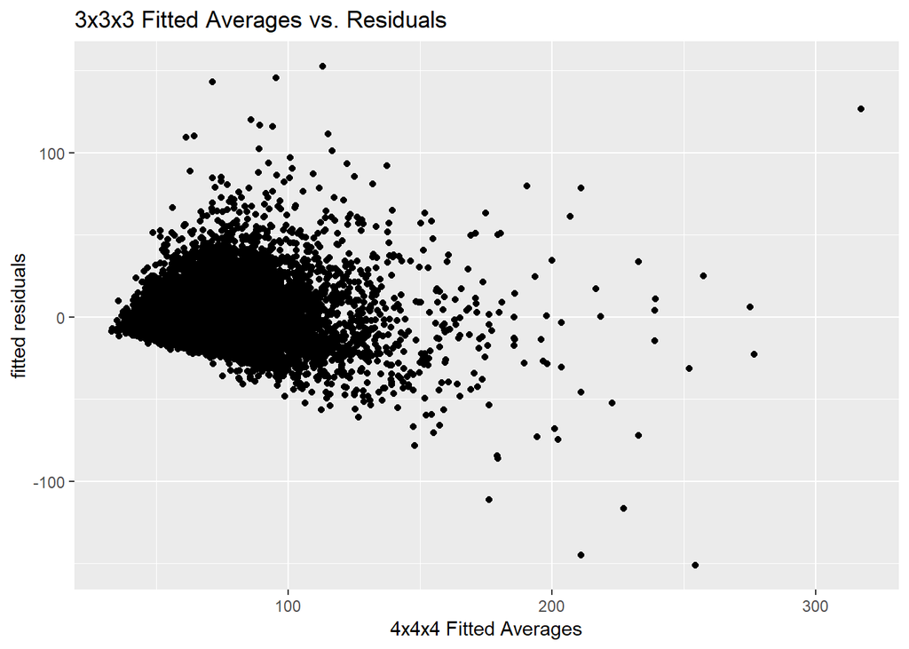

```r
mod34_resids <- augment(mod34)
ggplot(mod34_resids, aes(x=.fitted, y=.resid)) + geom_point() + labs(x="4x4x4 Fitted Averages", y="fitted residuals", title = "3x3x3 Fitted Averages vs. Residuals")
```

The residuals here are not amazing, but they’re not *completely* terrible. For smaller values (where the data is skewed), the residuals are pretty valid. Unfortunately, we can see the spread of the residuals really increase as we increase in solve time.

Just for fun, lets check the 3x3x3 vs 5x5x5 average too to see if they have the same issues.

### 3x3x3 vs. 5x5x5 model

The analysis here is the same as above. Note, I also drop all NA values here. This is important so that we can compare this model to the full model later.

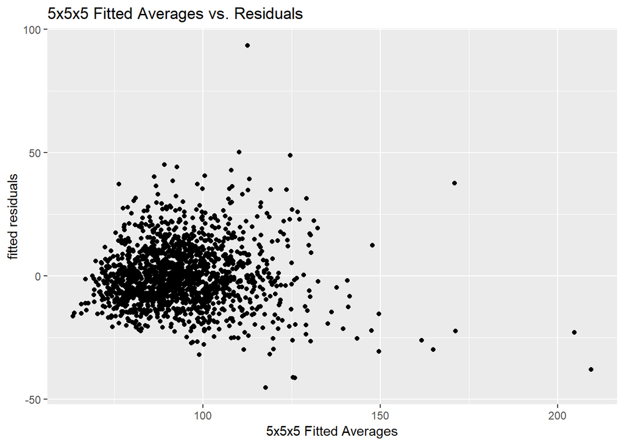

```r
samps <- drop_na(select(samp_avg, '333', '444', '555', '333oh', '666', '777'))
mod35 <- lm(samps$'555'~samps$'333', samps %>% drop_na())
mod35_resids <- augment(mod35)
ggplot(mod35_resids, aes(x=.fitted, y=.resid)) + geom_point() + labs(x="5x5x5 Fitted Averages", y="fitted residuals", title = "5x5x5 Fitted Averages vs. Residuals")
```

Surprisingly, the residuals here actually look a lot better here than with 4x4x4. For lower 3x3x3 averages, everything seems pretty valid. What this means to me is that the slope has a more complicated dependence on 3x3x3, which might be able to be handled by our full model!

### Full Model (No interaction terms)

```r
  full <- lm(samps$'555' ~ samps$'333' + samps$'444'+samps$'666' + samps$'777' + samps$'333oh', samps)
  broom::tidy(full)
```

```
## # A tibble: 6 x 5
##   term              estimate std.error statistic  p.value
##   <chr>                <dbl>     <dbl>     <dbl>    <dbl>
## 1 (Intercept)         6.40     0.973        6.57 6.75e-11
## 2 "samps$\"333\""     0.687    0.141        4.87 1.20e- 6
## 3 "samps$\"444\""     0.710    0.0383      18.5  2.15e-69
## 4 "samps$\"666\""     0.136    0.0124      11.0  5.48e-27
## 5 "samps$\"777\""     0.0591   0.00689      8.59 2.14e-17
## 6 "samps$\"333oh\""   0.0419   0.0370       1.13 2.57e- 1
```

If we look at the p-values here, all of them are $< \alpha = 0.05,$ except for One Handed. Let’s remove this and run it again. Conceptually, this makes a lot of sense, because of how slightly different it is to everything else.

```r
full <- lm(samps$'555' ~ samps$'333' + samps$'444'+samps$'666' + samps$'777', samps)
  broom::tidy(full)
```

```
## # A tibble: 5 x 5
##   term            estimate std.error statistic  p.value
##   <chr>              <dbl>     <dbl>     <dbl>    <dbl>
## 1 (Intercept)       6.23     0.962        6.47 1.28e-10
## 2 "samps$\"333\""   0.762    0.124        6.14 1.04e- 9
## 3 "samps$\"444\""   0.715    0.0381      18.8  6.79e-71
## 4 "samps$\"666\""   0.136    0.0124      11.0  5.05e-27
## 5 "samps$\"777\""   0.0591   0.00689      8.59 2.13e-17
```

Now, all of our p-values are good! They also make a lot more sense than the earlier models did. But is it actually better? We should do an ANOVA test to figure that out.

```r
anova(mod35, full)
```

```
## Analysis of Variance Table
##
## Model 1: samps$"555" ~ samps$"333"
## Model 2: samps$"555" ~ samps$"333" + samps$"444" + samps$"666" + samps$"777"
##   Res.Df    RSS Df Sum of Sq      F    Pr(>F)
## 1   1555 244790
## 2   1552  83551  3    161239 998.37 < 2.2e-16 ***
## ---
## Signif. codes:  0 '***' 0.001 '**' 0.01 '*' 0.05 '.' 0.1 ' ' 1
```

There are two indications from this ANOVA test that suggests that this model is better! The first is the F statistic, which is $>> 1$, implying that there is a significant relationship between the 5x5x5 average and any of the other averages. Also, the probability of this model having a larger F value by random chance is $2.2e-16 < \alpha=0.05$.

If we plot the residuals now, we get the following:

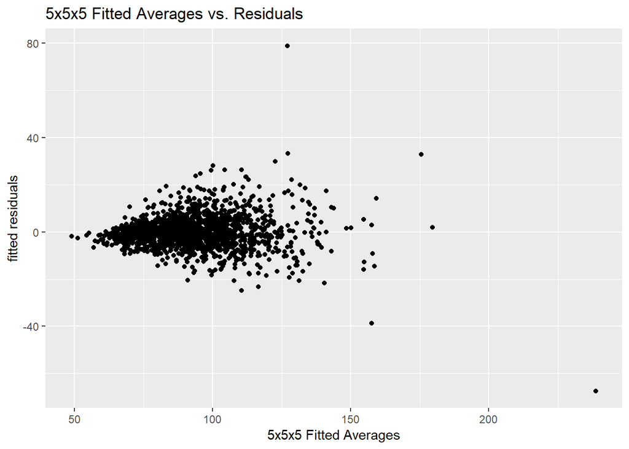

```r
full_resid <- augment(full)
ggplot(full_resid, aes(x=.fitted, y=.resid)) + geom_point() + labs(x="5x5x5 Fitted Averages", y="fitted residuals", title = "5x5x5 Fitted Averages vs. Residuals")
```

These residuals are pretty good! This means our model without interactions is fairly valid

Just to write it out explicitly, the model gives the following relationship:
$$555\_avg = 6.23 + 0.76*(333\_avg) + 0.71*(444\_avg) + 0.14*(666\_avg) + 0.06*(777\_avg)$$

### Full Model With Interaction

```r
full_inter <- lm(samps$'555' ~ samps$'333' *( samps$'444'+samps$'666' + samps$'777'), samps)
tidy(full_inter)
```

```
## # A tibble: 8 x 5
##   term                          estimate std.error statistic  p.value
##   <chr>                            <dbl>     <dbl>     <dbl>    <dbl>
## 1 (Intercept)                    1.27      3.18        0.399 6.90e- 1
## 2 "samps$\"333\""                0.929     0.265       3.50  4.70e- 4
## 3 "samps$\"444\""                1.21      0.0755     16.1   9.11e-54
## 4 "samps$\"666\""                0.107     0.0521      2.05  4.09e- 2
## 5 "samps$\"777\""                0.0105    0.0287      0.367 7.14e- 1
## 6 "samps$\"333\":samps$\"444\"" -0.0284    0.00401    -7.09  2.01e-12
## 7 "samps$\"333\":samps$\"666\""  0.00155   0.00368     0.422 6.73e- 1
## 8 "samps$\"333\":samps$\"777\""  0.00335   0.00205     1.63  1.03e- 1
```

```r
anova(full_inter, full)
```

```
## Analysis of Variance Table
##
## Model 1: samps$"555" ~ samps$"333" * (samps$"444" + samps$"666" + samps$"777")
## Model 2: samps$"555" ~ samps$"333" + samps$"444" + samps$"666" + samps$"777"
##   Res.Df   RSS Df Sum of Sq      F    Pr(>F)
## 1   1549 78823
## 2   1552 83551 -3   -4728.1 30.971 < 2.2e-16 ***
## ---
## Signif. codes:  0 '***' 0.001 '**' 0.01 '*' 0.05 '.' 0.1 ' ' 1
```

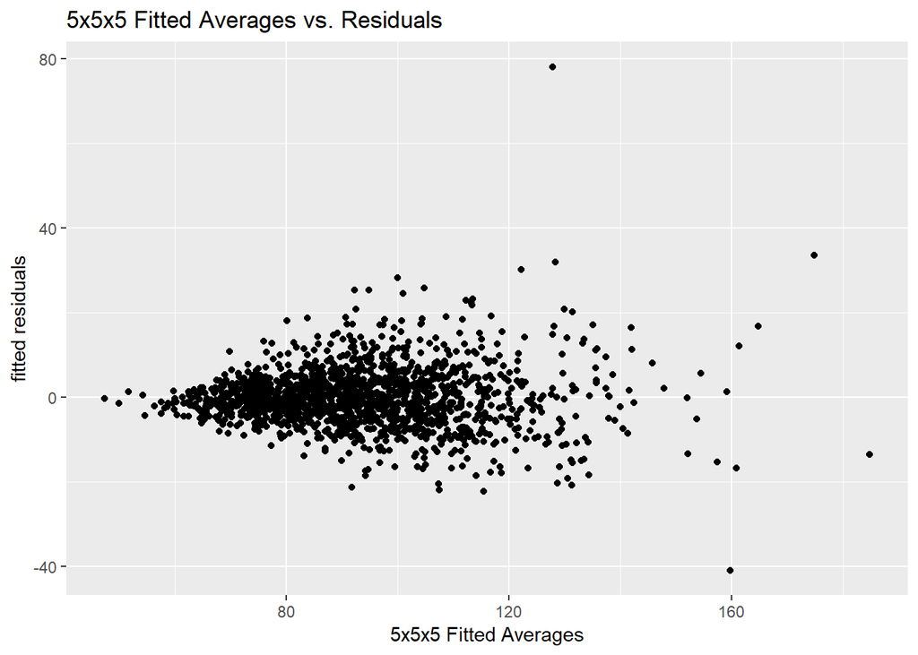

```r
full_inter_resid <- augment(full_inter)
ggplot(full_inter_resid, aes(x=.fitted, y=.resid)) + geom_point() + labs(x="5x5x5 Fitted Averages", y="fitted residuals", title = "5x5x5 Fitted Averages vs. Residuals")
```

### Min averages model

You may remember from the very top of this analysis where I said that we were going to analyze both the average averages and a persons best average. Here’s where I’ll do that. Much of the analysis leading up to this point is the same, so I’ll just get to the final model.

```r
samps <- drop_na(select(min_avgs, '333', '444', '555', '333oh', '666', '777'))
full_min <- lm(samps$'555' ~ samps$'333' +( samps$'444'+samps$'666' + samps$'777'), samps)
tidy(full_min)
```

```
## # A tibble: 5 x 5
##   term            estimate std.error statistic  p.value
##   <chr>              <dbl>     <dbl>     <dbl>    <dbl>
## 1 (Intercept)       5.63     0.819        6.87 9.02e-12
## 2 "samps$\"333\""   1.39     0.128       10.9  1.11e-26
## 3 "samps$\"444\""   0.592    0.0387      15.3  2.85e-49
## 4 "samps$\"666\""   0.153    0.0108      14.2  6.47e-43
## 5 "samps$\"777\""   0.0413   0.00573      7.20 9.14e-13
```

Again, all the p-values here are less than $\alpha=0.05$, so we expect them to be statistically significant. This is a good indication that our model is accurate.

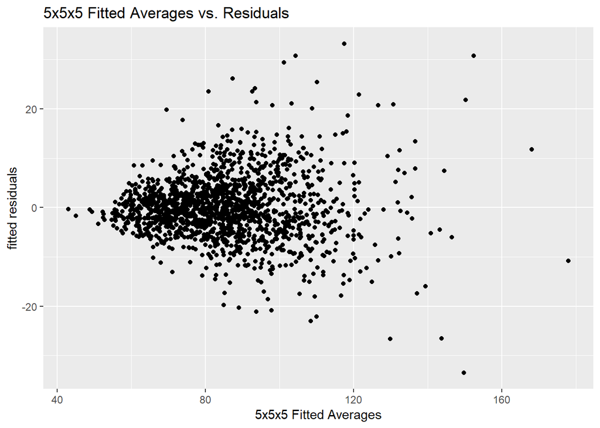

```r
min_resid <- augment(full_min)
ggplot(min_resid, aes(x=.fitted, y=.resid)) + geom_point() + labs(x="5x5x5 Fitted Averages", y="fitted residuals", title = "5x5x5 Fitted Averages vs. Residuals")
```

These residuals may *look* worse, but they’re actually way better! The range of the graph is smaller than before. This seems to imply that someones best performing averages are more closely linked together than their general/average performance. This model is:
$$555\_best = 5.62 + 1.392*(333\_avg) + 0.592*(444\_avg) + 0.153(666\_avg) + 0.041*(777\_avg)$$

## Conclusion

Throughout this analysis, we’ve been attempting to show that there is a relationship between someone’s average times to solve various sizes and forms of twisty puzzles. Even more strongly, we’ve developed a specific equation that can predict somebodies time on one puzzle given all of their other times.

The two equations we’ve derived are:

$$555\_avg = 6.23 + 0.76*(333\_avg) + 0.71*(444\_avg) + 0.14*(666\_avg) + 0.06*(777\_avg)$$
$$555\_best = 5.62 + 1.392*(333\_avg) + 0.592*(444\_avg) + 0.153(666\_avg) + 0.041*(777\_avg)$$

We chose to derive it in terms of of the 5x5x5 puzzle average, although the equation can be rederived to solve for any other term. We’ve shown through visually exploring the data that this analysis makes sense to do.

- 3x3x3 - 13.073
- 4x4x4 - 49.92
- 5x5x5 - 93.93
- 6x6x6 - 185.98
- 7x7x7 - 283.04

By using mulit-variate linear regression, we were able to create an accurate model that could predict times based off of peoples other results. The only real danger here, in my opinion, is overfitting. Furthermore, in context, sometimes people get very good at small puzzles, like the 3x3x3, but never practice the 7x7x7.

Further Reading and Sources:

- https://www.worldcubeassociation.org/